# Nieklasyczne metody statystyki

Regresja kwantylowa

Julia Deptulska

2024-11-30

## Dlaczego kwantylowa?

Dlaczego potrzebujemy regresji kwantylowej (QR)?

W szczególności, QR:

- jest odporna na punkty odstające i wpływowe
- nie zakłada stałej wariancji (znanej jako homoskedastyczność) dla zmiennej odpowiedzi lub reszt
- nie zakłada normalności ale główną zaletą QR w porównaniu z regresją liniową (LR) jest to, że QR bada różne wartości zmiennej odpowiedzi, a nie tylko średnią, i dostarcza w związku z tym pełniejszego obrazu związków między zmiennymi!

## Wprowadzenie

Regresja kwantylowa (ang. quantile regression) została zaproponowana przez Koenkera i Bassetta (1978). Szczególny przypadek regresji kwantylowej dla kwantyla rzędu 0,5 (czyli mediany) jest równoważny estymatorowi LAD (ang. Least Absolute Deviation) – minimalizuje sumę bezwzględnych błędów.  
Wprowadzenie różnych kwantyli regresji daje pełniejszy opis rozkładów warunkowych zwłaszcza w przypadku rozkładów asymetrycznych lub uciętych.

Regresja kwantylowa jest kolejną wariacją na temat najmniejszych kwadratów . Stratą jest współczynnik $l_1$ funkcji:

$$\phi(u) = \tau\max(u,0) - (1-\tau)\max(-u,0) = \frac{1}{2}|u| +
\left(\tau - \frac{1}{2}\right)u,$$

gdzie $\tau \in (0,1)$ oznacza konkretny kwantyl. Problemem jak poprzednio jest minimalizacja całkowitej straty resztowej. Model ten jest powszechnie stosowany w ekologii, ochronie zdrowia i innych dziedzinach, gdzie sama średnia nie wystarcza do uchwycenia złożonych zależności między zmiennymi.

## Wymagania

Wymagana jest jedna liczbowa zmienna zależna. Zmienna przewidywana musi być zmienną ilościową. Predyktory mogą być zmiennymi ilościowymi lub sztucznymi zmiennymi w przypadku predyktorów jakościowych. Aby można było uruchomić analizę, wymagany jest wyraz wolny lub co najmniej jeden predyktor.

Regresja kwantylowa nie czyni założeń dotyczących rozkładu zmiennej przewidywanej i jest odporna na wpływ obserwacji odstających.

Analiza kwantylowa jest pokrewna regresji metodą najmniejszych kwadratów.

## Przykład 1.

Wykorzystamy przykład z pakietu quantreg.

Jaki jest związek między całkowitym dochodem gospodarstwa domowego a odsetkiem dochodów wydatkowanych na żywność? Prawo Engela w ekonomii głosi, że w miarę wzrostu dochodów, część dochodów wydatkowanych na żywność spada, nawet jeśli wydatki na żywność bezwzględnie rosną. Stosując regresję kwantylową do tych danych, można określić, jakie wydatki na żywność ponosi 90% rodzin (dla 100 rodzin z danym dochodem), gdy nie interesują nas średnie wydatki na żywność.

Dane, które wykorzystamy - to zbiór “engel” - dane dotyczące wydatków na żywność. Jest to zbiór danych regresyjnych składający się z 235 obserwacji dotyczących dochodów i wydatków na żywność dla belgijskich gospodarstw domowych klasy robotniczej.

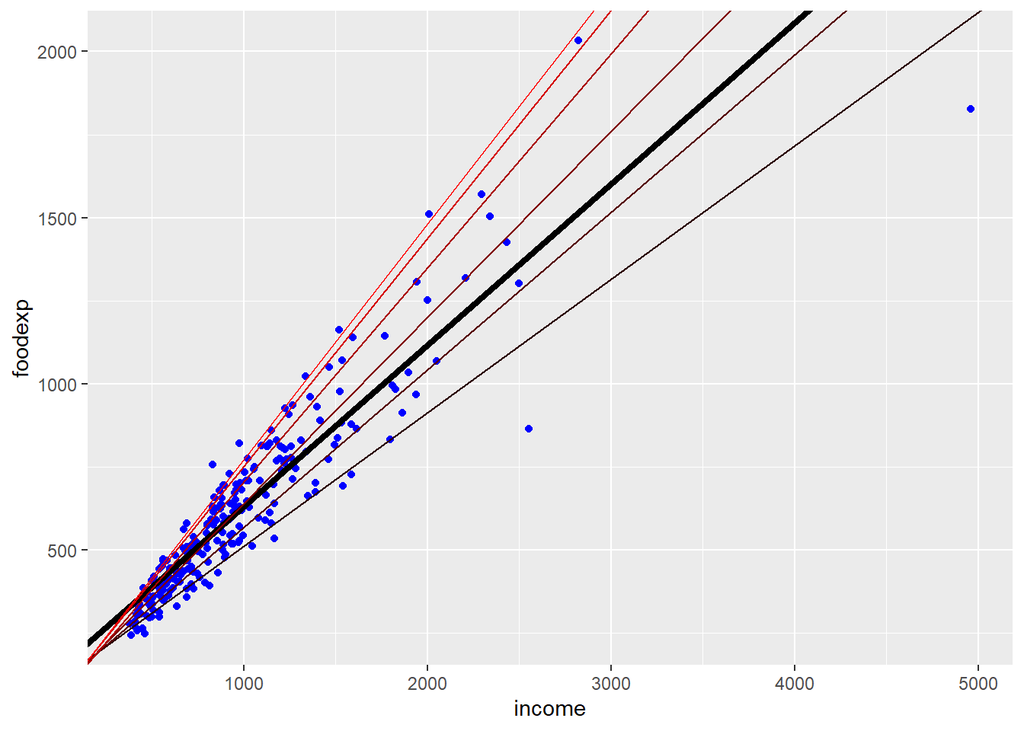

Powyższy wykres przedstawia dopasowanie regresji kwantylowej dla $\tau = (0.1, 0.25, 0.5, 0.75, 0.90, 0.95)$. Dopasowanie KMNK to gruba czarna linia.

Poniżej znajduje się tabela z oszacowanymi współczynnikami.

```r
knitr::kable(fits, format = "html", caption = "Oszacowania z KMNK oraz `quantreg`") %>%
    kable_styling("striped") %>%
    column_spec(1:8, background = "#ececec")
```

Oszacowania z KMNK oraz `quantreg`

|  | OLS | $\tau_{0.10}$ | $\tau_{0.25}$ | $\tau_{0.50}$ | $\tau_{0.75}$ | $\tau_{0.90}$ | $\tau_{0.95}$ |
| --- | --- | --- | --- | --- | --- | --- | --- |
| (Intercept) | 147.4753885 | 110.1415742 | 95.4835396 | 81.4822474 | 62.3965855 | 67.3508721 | 64.1039632 |
| income | 0.4851784 | 0.4017658 | 0.4741032 | 0.5601806 | 0.6440141 | 0.6862995 | 0.7090685 |

Ok, możemy to zrobić bardziej przejrzyście i sformatować w ładnej tabeli wyników:

```
##
## Wyniki regresji kwantylowych
## ==========================================
##                   Dependent variable:
##              -----------------------------
##                         foodexp
##                 (1)       (2)       (3)
## ------------------------------------------
## income       0.474***  0.560***  0.644***
##               (0.029)   (0.028)   (0.023)
##
## Constant     95.484*** 81.482*** 62.397***
##              (21.392)  (19.251)  (16.305)
##
## ------------------------------------------
## Observations    235       235       235
## ==========================================
## Note:          *p<0.1; **p<0.05; ***p<0.01
```

Finalnie, zaprezentujmy wyłącznie te 3 modele na wykresie:

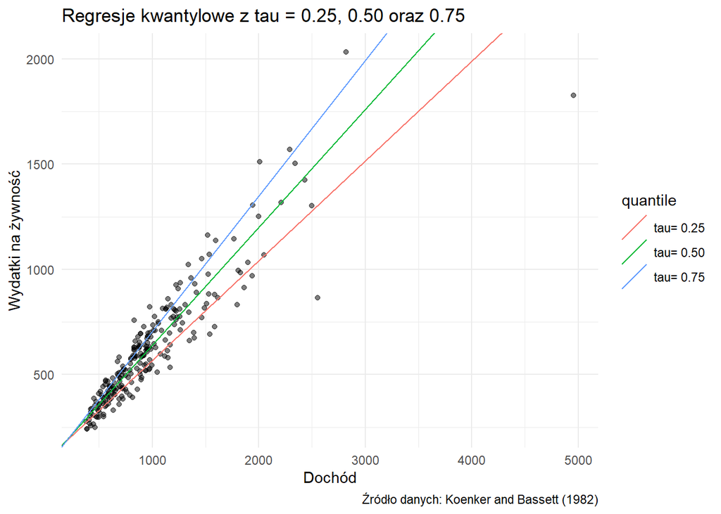

## Przykład 2.

Tutaj przeprowadzimy testy użycia pakietu quantreg, wykorzystując wbudowany zbiór danych “**mtcars**”. Zmienna “**mpg**” oznacza spalanie samochodów (*mile/galon*).

Zamodulejmy zależność regresyjną dla tej zmiennej od kilku predyktorów.

Najpierw oszacujmy regresję KMNK:

```r
kmnk <- lm(mpg ~ disp + hp + factor(am) + factor(vs), data = mtcars)
summary(kmnk)
```

```
##
## Call:
## lm(formula = mpg ~ disp + hp + factor(am) + factor(vs), data = mtcars)
##
## Residuals:
##     Min      1Q  Median      3Q     Max
## -4.7981 -1.9532  0.0111  1.5665  5.6321
##
## Coefficients:
##              Estimate Std. Error t value Pr(>|t|)
## (Intercept) 24.832119   2.890418   8.591 3.32e-09 ***
## disp        -0.008304   0.010087  -0.823  0.41757
## hp          -0.037623   0.013846  -2.717  0.01135 *
## factor(am)1  4.419257   1.493243   2.960  0.00634 **
## factor(vs)1  2.052472   1.627096   1.261  0.21794
## ---
## Signif. codes:  0 '***' 0.001 '**' 0.01 '*' 0.05 '.' 0.1 ' ' 1
##
## Residual standard error: 2.812 on 27 degrees of freedom
## Multiple R-squared:  0.8104, Adjusted R-squared:  0.7823
## F-statistic: 28.85 on 4 and 27 DF,  p-value: 2.13e-09
```

Teraz oszacujmy warunkowe regresje kwantylowe na różnych kwantylach, błąd standardowy uzyskany przez *bootstrap*.

Zauważ, że istnieje gradient we współczynnikach kwantylowych **hp**, jak również **disp**. Znak **disp** odwraca się, również współczynnik na czynniku **am** jest różny w zależności od kwantyli:

```r
kwantyle <- c(0.25, 0.50, 0.75)
regkw <- rq(mpg ~ disp + hp + factor(am),tau = kwantyle,data = mtcars)
summary(regkw, se = "boot")
```

```
##
## Call: rq(formula = mpg ~ disp + hp + factor(am), tau = kwantyle, data = mtcars)
##
## tau: [1] 0.25
##
## Coefficients:
##             Value    Std. Error t value  Pr(>|t|)
## (Intercept) 25.34665  1.64114   15.44457  0.00000
## disp        -0.02441  0.00828   -2.94865  0.00638
## hp          -0.01672  0.01452   -1.15144  0.25929
## factor(am)1  1.39719  1.37790    1.01400  0.31926
##
## Call: rq(formula = mpg ~ disp + hp + factor(am), tau = kwantyle, data = mtcars)
##
## tau: [1] 0.5
##
## Coefficients:
##             Value    Std. Error t value  Pr(>|t|)
## (Intercept) 27.49722  1.87496   14.66547  0.00000
## disp        -0.02253  0.01545   -1.45817  0.15592
## hp          -0.02713  0.02213   -1.22619  0.23034
## factor(am)1  3.37328  1.98612    1.69843  0.10051
##
## Call: rq(formula = mpg ~ disp + hp + factor(am), tau = kwantyle, data = mtcars)
##
## tau: [1] 0.75
##
## Coefficients:
##             Value    Std. Error t value  Pr(>|t|)
## (Intercept) 28.06384  1.91345   14.66661  0.00000
## disp         0.00445  0.01348    0.33039  0.74357
## hp          -0.06662  0.01609   -4.14162  0.00029
## factor(am)1  7.91402  2.34193    3.37928  0.00215
```

### Testy współczynników

Użyjemy funkcji rq.anova z pakietu regresji kwantylowej, aby przeprowadzić test WALDA. Pamiętaj, że test WALDA mówi, że biorąc pod uwagę nieograniczone oszacowania modelu, przetestujemy hipotezę zerową mówiącą, że współczynniki spełniają pewne liniowe ograniczenia.

Aby ją przetestować, użyjemy obiektu zwróconego z uruchomienia *rq* z różnymi liczbami kwantyli i ustawimy opcję *joint* na true lub false. Gdy *joint* jest true: “równość współczynników kierunkowych powinna być wykonana jako wspólne testy na wszystkich parametrach nachylenia”, gdy *joint* jest false: “należy zgłaszać oddzielne testy na każdym z parametrów nachylenia”.

Zauważ, że testy kwantylowe są testami “linii równoległej”. Oznacza to, że powinniśmy wyjąć różne x-wyrazy_wolne dla każdego kwantyla, ponieważ reprezentują one poziomy rozkładów warunkowych. Jeśli jednak współczynniki kwantyli dla współczynnikow są takie same, to nie ma efektów specyficznych dla kwantyli, wystarczą efekty średnie.

**Badanie statystycznej różnicy między 25. i 50. kwantylem warunkowym:**

Biorąc pod uwagę powyższe oszacowania kwantyli, różnica między kwantylami 0,25 i 0,50 istnieje, ale czy są one wystarczająco duże, aby być statystycznie różne? Jaka jest wartość p? Przeglądając poniższe wyniki, nie są one statystycznie różne!

Po pierwsze, joint = TRUE. To nie jest testowanie, czy współczynnik na disp jest taki sam jak współczynnik na hp. To jest wspólne testowanie, czy współczynniki dla różnych kwantyli disp i różnych kwantyli hp są takie same dla każdej zmiennej.

```r
kwantyle <- c(0.25, 0.50)
regkw <- rq(mpg ~ disp + hp + factor(am),tau = kwantyle, data = mtcars)
anova(regkw, test = "Wald", joint=TRUE)
```

```
## Quantile Regression Analysis of Deviance Table
##
## Model: mpg ~ disp + hp + factor(am)
## Joint Test of Equality of Slopes: tau in {  0.25 0.5  }
##
##   Df Resid Df F value Pr(>F)
## 1  3       61  0.8421 0.4761
```

Po drugie, joint = False:

```r
anova(regkw, test = "Wald", joint=FALSE)
```

```
## Quantile Regression Analysis of Deviance Table
##
## Model: mpg ~ disp + hp + factor(am)
## Tests of Equality of Distinct Slopes: tau in {  0.25 0.5  }
##
##             Df Resid Df F value Pr(>F)
## disp         1       63  0.0305 0.8619
## hp           1       63  0.5461 0.4627
## factor(am)1  1       63  1.3500 0.2497
```

**Badanie statystycznej różnicy między 25, 50 i 75 kwantylem warunkowym:**

Pierwszy kwartyl i mediana nie wydają się być statystycznie różne, teraz dołączymy trzeci kwartyl. Jak widać wcześniej, kwartyle wspólnie wykazują gradient. Teraz możemy zobaczyć, że **disp**, **hp** i **am** są oddzielnie statystycznie różne.

Po pierwsze, joint = TRUE:

```r
kwantyle <- c(0.25, 0.50, 0.75)

regkw <- rq(mpg ~ disp + hp + factor(am),tau = kwantyle, data = mtcars)

anova(regkw, test = "Wald", joint=TRUE)
```

```
## Quantile Regression Analysis of Deviance Table
##
## Model: mpg ~ disp + hp + factor(am)
## Joint Test of Equality of Slopes: tau in {  0.25 0.5 0.75  }
##
##   Df Resid Df F value   Pr(>F)
## 1  6       90  3.3173 0.005367 **
## ---
## Signif. codes:  0 '***' 0.001 '**' 0.01 '*' 0.05 '.' 0.1 ' ' 1
```

Po drugie, joint = False:

```r
anova(regkw, test = "Wald", joint=FALSE)
```

```
## Quantile Regression Analysis of Deviance Table
##
## Model: mpg ~ disp + hp + factor(am)
## Tests of Equality of Distinct Slopes: tau in {  0.25 0.5 0.75  }
##
##             Df Resid Df F value   Pr(>F)
## disp         2       94  5.4903 0.005558 **
## hp           2       94  6.7221 0.001868 **
## factor(am)1  2       94  7.2758 0.001154 **
## ---
## Signif. codes:  0 '***' 0.001 '**' 0.01 '*' 0.05 '.' 0.1 ' ' 1
```

### Dobroć dopasowania

```r
goodfit(resid, resid_nl, tau)
```

Miara dobroci dopasowania dla regresji kwantylowej jest szacowana jako 1 minus stosunek sumy odchyleń bezwzględnych w modelach w pełni sparametryzowanych do sumy odchyleń bezwzględnych w zerowym (bezwarunkowym) modelu kwantylowym.

Wartości te są przydatne do porównań między modelami kwantylowymi, ale nie są porównywalne ze standardowymi współczynnikami determinacji. Te ostatnie oparte są na wariancji odchyleń kwadratowych, natomiast wartości dobroci dopasowania dla regresji kwantylowej oparte są na odchyleniach bezwzględnych. Wartości dobroci dopasowania zawsze będą mniejsze niż wartości R<sup>2</sup>.

```r
## model kwantylowy
model1 <- rq(mpg ~ disp + hp + factor(am),tau = 0.5, data = mtcars)
reszty1 <- resid(model1)

## bezwarunkowy (pusty) model kwantylowy
model2 <- rq(mpg ~ 1, tau = 0.5,data=mtcars)
reszty2 <- resid(model2)

library(vcd)
#goodfit(reszty1, reszty2, 0.5)

## r2 modelu KMNK dla porównania
model_lm <- lm(mpg ~ disp + hp + factor(am), data = mtcars)

summary(model_lm)$r.squared
```

```
## [1] 0.7992061
```

## Zadanie

Teraz Wasza kolej ;-)

Waszym zadaniem dzisiaj jest zamodelowanie - porównanie KMNK oraz regresji kwantylowej (różno-poziomowej) dla zmiennej “earnings” - wynagrodzenia.

Dobierz i przetestuj predyktory, kwantyle dla modeli. Wykonaj testy różnic współczynnikow dla finalnych modeli.

W przypadku problemów - obejrzyj video tutorial (włącz polskie napisy) oraz wejdź na jego stronę ze źródłami. Możesz również wykorzystać w/w przykłady.

```r
data("CPSSW9298")
dane <- CPSSW9298
```

#Regesja KMNK

```r
kmnk <- lm(earnings ~ age + degree + gender, data = dane)
summary(kmnk)
```

```
##
## Call:
## lm(formula = earnings ~ age + degree + gender, data = dane)
##
## Residuals:
##     Min      1Q  Median      3Q     Max
## -15.023  -3.735  -0.819   2.755  33.526
##
## Coefficients:
##                Estimate Std. Error t value Pr(>|t|)
## (Intercept)     1.70477    0.52435   3.251  0.00115 **
## age             0.33245    0.01740  19.106  < 2e-16 ***
## degreebachelor  4.91123    0.09938  49.418  < 2e-16 ***
## genderfemale   -2.24217    0.09902 -22.643  < 2e-16 ***
## ---
## Signif. codes:  0 '***' 0.001 '**' 0.01 '*' 0.05 '.' 0.1 ' ' 1
##
## Residual standard error: 5.665 on 13497 degrees of freedom
## Multiple R-squared:  0.1877, Adjusted R-squared:  0.1876
## F-statistic:  1040 on 3 and 13497 DF,  p-value: < 2.2e-16
```

Według modelu wiek, poziom wykształcenia - tytuł licencjata i bycie kobietą wpływają na wynagrodzenie.

# Regresja kwantylowa

```r
kwantyle <- c(0.25, 0.50, 0.75)
regkw <- rq(earnings ~ age + degree + gender , tau = kwantyle, data = dane)
summary(regkw, se = "boot")
```

```
##
## Call: rq(formula = earnings ~ age + degree + gender, tau = kwantyle,
##     data = dane)
##
## tau: [1] 0.25
##
## Coefficients:
##                Value     Std. Error t value   Pr(>|t|)
## (Intercept)      2.67308   0.42935    6.22587   0.00000
## age              0.17308   0.01496   11.56982   0.00000
## degreebachelor   3.59188   0.07864   45.67400   0.00000
## genderfemale    -1.32265   0.08261  -16.01073   0.00000
##
## Call: rq(formula = earnings ~ age + degree + gender, tau = kwantyle,
##     data = dane)
##
## tau: [1] 0.5
##
## Coefficients:
##                Value     Std. Error t value   Pr(>|t|)
## (Intercept)      1.45427   0.54933    2.64734   0.00812
## age              0.31389   0.01865   16.83277   0.00000
## degreebachelor   4.70043   0.11522   40.79640   0.00000
## genderfemale    -2.12970   0.11275  -18.88814   0.00000
##
## Call: rq(formula = earnings ~ age + degree + gender, tau = kwantyle,
##     data = dane)
##
## tau: [1] 0.75
##
## Coefficients:
##                Value     Std. Error t value   Pr(>|t|)
## (Intercept)      1.53846   0.90068    1.70812   0.08764
## age              0.43269   0.02924   14.79758   0.00000
## degreebachelor   5.75962   0.14732   39.09517   0.00000
## genderfemale    -2.97009   0.13293  -22.34310   0.00000
```

Dla pierwszego, drugiego kwartyla i trzeciego kwartyla wszystkie zmienne są istotnie statystycznie.

# Testy współczynników

```r
anova(regkw, test = "Wald", joint=TRUE)
```

```
## Quantile Regression Analysis of Deviance Table
##
## Model: earnings ~ age + degree + gender
## Joint Test of Equality of Slopes: tau in {  0.25 0.5 0.75  }
##
##   Df Resid Df F value    Pr(>F)
## 1  6    40497   90.65 < 2.2e-16 ***
## ---
## Signif. codes:  0 '***' 0.001 '**' 0.01 '*' 0.05 '.' 0.1 ' ' 1
```

Wartość p=value wskazuje na to, że łącznie kwartyle różnią się od siebie statystycznie.

```r
anova(regkw, test = "Wald", joint=FALSE)
```

```
## Quantile Regression Analysis of Deviance Table
##
## Model: earnings ~ age + degree + gender
## Tests of Equality of Distinct Slopes: tau in {  0.25 0.5 0.75  }
##
##                Df Resid Df F value    Pr(>F)
## age             2    40501  72.465 < 2.2e-16 ***
## degreebachelor  2    40501 117.817 < 2.2e-16 ***
## genderfemale    2    40501  88.771 < 2.2e-16 ***
## ---
## Signif. codes:  0 '***' 0.001 '**' 0.01 '*' 0.05 '.' 0.1 ' ' 1
```

Wymienione zmienne są łącznie oddzielnie od siebie różne.

# Dobroć dopasowania

```r
summary(kmnk)$r.squared
```

```
## [1] 0.1877333
```

Modl kmnk dopasowuje się niezbyt dobrze do danych.